# Logistic Regression in R

Dan Polson

# 1 Hiroshima Data

The numbers of deaths from leukemia and other cancers among survivors of the Hiroshima atom bomb are given in the dataset Hiroshima.csv, classified by radiation dose received. The variable ‘Rad’ is approximately the midpoint of the radiation dose interval. We are interested in the dose-response association between radiation dose (Rad) and the cancer mortality rates for leukemia.

```r
#Empirical logit function to prevent errors
emplogit <- function(y, n){ log((y +.5)/(n - y + .5))}

#Load in data
Hiro.dat <- read.csv('~/Desktop/Hiroshima.csv')
Hiro.dat
```

```
##    radiation     rad Rad leukemia othercancer totalcancers
## 1          0       0   0       13         378          391
## 2     1 to 9     1-9   5        5         200          205
## 3   10 to 49   10-49  30        5         151          156
## 4   50 to 99   50-99  75        3          47           50
## 5 100 to 199 100-199 150        4          31           35
## 6      200 +    200+ 200       18          33           51
```

# 2 Plots

Our first plot will plot our observed proportions of Leukemia deaths relative to total cancer deaths versus radiation dose. This plot will also include an approximate 95% confidence interval for each data point.

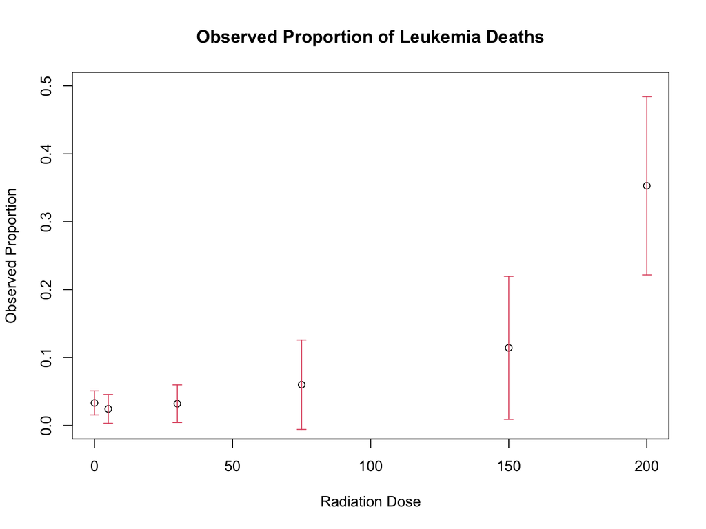

```r
#Create Proportion Column
Hiro.dat$prop <- Hiro.dat$leukemia/Hiro.dat$totalcancers

#=Create Approximate Upper and Lower Bounds
#For 95% CI's
Hiro.dat <- within(Hiro.dat, {
upper <- prop + 1.96 * sqrt(prop*(1-prop)/totalcancers)
lower <- prop - 1.96 * sqrt(prop*(1-prop)/totalcancers)
}
)

##Plot data points with CI's
with(Hiro.dat, {
  plot(Rad, prop, ylim = c(0,0.5), ylab = "Observed Proportion", xlab = "Radiation Dose",
       main = "Observed Proportion of Leukemia Deaths")
  arrows(Rad[1:6], lower[1:6], Rad[1:6], upper[1:6],
  length=0.05, angle=90, code=3, col=2)

}
)
```

Our second plot will plot the logit of the observed proportion versus radiation dose.

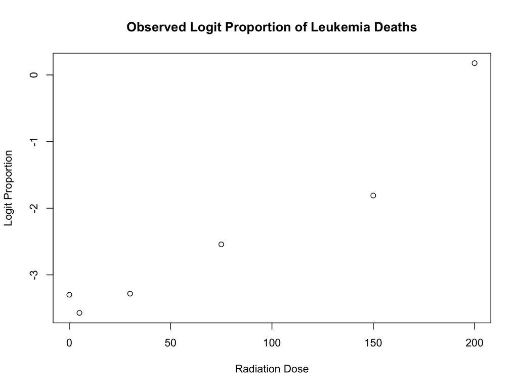

```r
with(Hiro.dat,
plot(Rad, emplogit(leukemia, othercancer), main='Observed Logit Proportion of Leukemia Deaths',
xlab='Radiation Dose', ylab='Logit Proportion')
)
```

From these plots, we observe that there appears to be some positive correlation between radiation dose and the proportion of leukemia deaths.

# 3 Fit the glm models

We’ll try a number of logistic-style models, including logit, probit, and complementary log-link models. These three models are denoted by,
$$\text{logit}(\pi_{i}) = \text{log}(\frac{\pi_i}{1- \pi_i}) = \beta_{1} + \beta_{2} \cdot \text{Rad}$$
$$\text{probit}(\pi_{i}) = \Phi^{-1}(\pi_{i}) = \beta_{1} + \beta_{2} \cdot \text{Rad}$$
$$\text{cloglog}(\pi_{i}) = \text{log}[-\text{log}(1- \pi_{i})] = \beta_{1} + \beta_{2} \cdot \text{Rad}$$
respectively, where $\pi_{i}$ is the probability of a cancer death being caused by leukemia given radiation dose $\text{Rad}_{i}$, and $\Phi(z)$ is the standard normal cdf.

```r
#Logit-link Function
Hiro.glm1 <- glm(cbind(leukemia, othercancer) ~ Rad, family=binomial(link="logit"),
data=Hiro.dat)
summary(Hiro.glm1)
```

```
##
## Call:
## glm(formula = cbind(leukemia, othercancer) ~ Rad, family = binomial(link = "logit"),
##     data = Hiro.dat)
##
## Deviance Residuals:
##       1        2        3        4        5        6
##  0.8247  -0.3343  -0.4967  -0.3357  -1.0985   0.6568
##
## Coefficients:
##              Estimate Std. Error z value Pr(>|z|)
## (Intercept) -3.611334   0.219403 -16.460  < 2e-16 ***
## Rad          0.014054   0.001848   7.603 2.89e-14 ***
## ---
## Signif. codes:  0 '***' 0.001 '**' 0.01 '*' 0.05 '.' 0.1 ' ' 1
##
## (Dispersion parameter for binomial family taken to be 1)
##
##     Null deviance: 54.3509  on 5  degrees of freedom
## Residual deviance:  2.7893  on 4  degrees of freedom
## AIC: 28.454
##
## Number of Fisher Scoring iterations: 4
```

```r
#Probit-link Function
Hiro.glm2 <- glm(cbind(leukemia, othercancer) ~ Rad, family=binomial(link="probit"),
data=Hiro.dat)
summary(Hiro.glm2)
```

```
##
## Call:
## glm(formula = cbind(leukemia, othercancer) ~ Rad, family = binomial(link = "probit"),
##     data = Hiro.dat)
##
## Deviance Residuals:
##       1        2        3        4        5        6
##  0.8790  -0.3275  -0.6187  -0.5074  -1.1882   0.8495
##
## Coefficients:
##               Estimate Std. Error z value Pr(>|z|)
## (Intercept) -1.9450521  0.0945417 -20.573  < 2e-16 ***
## Rad          0.0070697  0.0009823   7.197 6.15e-13 ***
## ---
## Signif. codes:  0 '***' 0.001 '**' 0.01 '*' 0.05 '.' 0.1 ' ' 1
##
## (Dispersion parameter for binomial family taken to be 1)
##
##     Null deviance: 54.3509  on 5  degrees of freedom
## Residual deviance:  3.6536  on 4  degrees of freedom
## AIC: 29.319
##
## Number of Fisher Scoring iterations: 4
```

```r
#Complementary Log Log Link Function
Hiro.glm3 <- glm(cbind(leukemia, othercancer) ~ Rad, family=binomial(link="cloglog"),
data=Hiro.dat)
summary(Hiro.glm3)
```

```
##
## Call:
## glm(formula = cbind(leukemia, othercancer) ~ Rad, family = binomial(link = "cloglog"),
##     data = Hiro.dat)
##
## Deviance Residuals:
##       1        2        3        4        5        6
##  0.8030  -0.3425  -0.4718  -0.2830  -1.0427   0.5526
##
## Coefficients:
##              Estimate Std. Error z value Pr(>|z|)
## (Intercept) -3.618197   0.215140 -16.818  < 2e-16 ***
## Rad          0.013262   0.001662   7.981 1.45e-15 ***
## ---
## Signif. codes:  0 '***' 0.001 '**' 0.01 '*' 0.05 '.' 0.1 ' ' 1
##
## (Dispersion parameter for binomial family taken to be 1)
##
##     Null deviance: 54.3509  on 5  degrees of freedom
## Residual deviance:  2.4573  on 4  degrees of freedom
## AIC: 28.122
##
## Number of Fisher Scoring iterations: 4
```

From these models, we can choose the one which best minimizes Akaike’s Information Criterion (AIC), and overall residual deviance. In this case, the complementary log-link model minimizes both relative to the other two models, so we choose the model:
$$\text{cloglog}(\pi_{i}) = \text{log}[-\text{log}(1- \pi_{i})] = -3.618 + 0.013 \cdot \text{Rad}$$
When testing $H_{0}: B_{i} = 0$ for $i = 1,2$, versus alternative $H_{1}: B_{i} \neq 0$, we obtain p-values which are both significantly less than $\alpha = 0.001$ (as seen in the summary table above), so we can say with a high-degree of confidence that our regression coefficients are both nonzero. From this, we can deduce that there is some association between radiation dose and leukemia cancer mortality. It remains to check our model fit with goodness-of-fit statistics.

# 4 Plot the fitted model

We’ll show our chosen model as it compares to the other two.

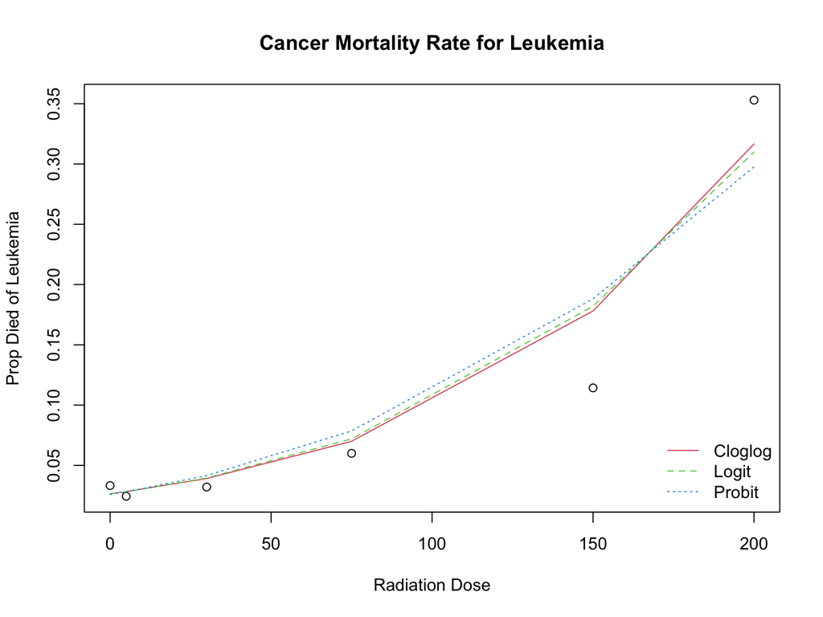

```r
with(Hiro.dat,
{
plot(Rad, prop, main='Cancer Mortality Rate for Leukemia',
xlab='Radiation Dose', ylab='Prop Died of Leukemia')
lines(Rad, fitted(Hiro.glm3), col=2, lty=1)
lines(Rad, fitted(Hiro.glm1), col=3, lty=2)
lines(Rad, fitted(Hiro.glm2), col=4, lty=3)
}
)

legend('bottomright', c("Cloglog","Logit","Probit"),
col=2:4, lty=1:3 ,bty="n")
```

# 5 Goodness-of-fit statistics

```r
# Deviance and chi-square .95 quantile for goodness-of-fit statistic
anova(Hiro.glm3, test='Chisq')
```

```
## Analysis of Deviance Table
##
## Model: binomial, link: cloglog
##
## Response: cbind(leukemia, othercancer)
##
## Terms added sequentially (first to last)
##
##
##      Df Deviance Resid. Df Resid. Dev  Pr(>Chi)
## NULL                     5     54.351
## Rad   1   51.894         4      2.457 5.859e-13 ***
## ---
## Signif. codes:  0 '***' 0.001 '**' 0.01 '*' 0.05 '.' 0.1 ' ' 1
```

Here, we perform the Pearson’s $\chi^2$ test.

```r
SIG <- qchisq(0.95,4)

X1 <- sum(residuals(Hiro.glm3, type='pearson')^2)
X1; paste('pvalue =', pchisq(X1, 4, lower.tail = FALSE))
```

```
## [1] 2.3789
```

```
## [1] "pvalue = 0.666443599786823"
```

We get a p-value of $\approx 0.666$, so our model fit is adequate. Next, we check the pseudo-$R^2$ value:

```r
Hiro.glm0 <- glm(cbind(leukemia, othercancer) ~ 1, family=binomial(link="cloglog"),
data=Hiro.dat)
PseudoR <- (logLik(Hiro.glm0)-logLik(Hiro.glm3))/logLik(Hiro.glm0)
PseudoR
```

```
## 'log Lik.' 0.682668 (df=1)
```

This is a high pseudo-$R^2$ value, so both of our goodness-of-fit tests show that our model fits the data well.

# 6 Residuals

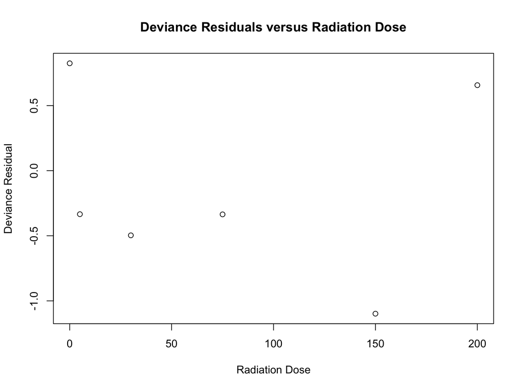

```r
with(Hiro.dat,
     plot(Rad, residuals(Hiro.glm1, "deviance"),
          xlab = "Radiation Dose",
          ylab = "Deviance Residual",
          main = "Deviance Residuals versus Radiation Dose")
)
```

# 7 Conclusion/Summary

Following the dropping of the atom bomb on Hiroshima, the numbers of deaths caused by leukemia and other cancers were noted for survivors. The goal of this research was to test for correlation between radiation dose and cancer mortality rates for leukemia based on these survivors (and develop a model for the phenomenon). After testing some models, we found that a complementary log log model was best fit for our data. This model suggests that with an increase in dosage of radiation comes an increase in relative cancer mortality rate for leukemia (See Cancer Mortality Rate for Leukemia graph above). The evidence seems to point towards leukemia occurring proportionally more under high dosages of radiation than other cancers.